# Predicting Lifespan: A Data-Driven Look at Health and Lifestyle Factors

#### Spring 2025 CMSC320 Project

#### By: Kaylee Wolf, Sahil Mehta, Guang-Lin Wei, and Saketh Vegunta

1. Introduction
2. Data Cleaning
3. Exploratory Data Analysis
4. Modeling
5. Visualization
6. Insights and Conclusions

### Contributions

- A: Project idea :
- Everyone found two datasets that seemed interesting, then we voted on the one to continue with
- B: Dataset Curation and Preprocessing :
- I loaded a JSON file into pandas, cleaned it up by converting data to the right types, removed any duplicates or missing values, organized the columns in a consistent order, and saved the cleaned version as a CSV to use in the next steps of the project (Kaylee Wolf).
- C: Data Exploration and Summary Statistics :
- I did part two of the data exploration: Do males and females have significantly different average ages at death? I wanted to see if men and women tend to die at different average ages, so I split the data by sex and compared their average ages using a t-test. This gave me a t-statistic and p-value to tell whether the difference is statistically significant, and I also plotted the age distributions to visualize how they compare (Kaylee Wolf).
- I did part 1 of the data exploration, seeing if any numerical factors (systolic blood pressure, height, weight, and cholesterol level) were correlated with age of death (Guang-Lin Wei).
- I did part 3 of the data exploration seeing if heart disease or stroke had any noticable impact on the age distributions. I used the t-test to get the t-statistic and p-value, allowing me to come to a conclusion. By visualizing the data, I was able to make a conclusion on how the skewedness of the data affected the age of death for the HD/s group (Sahil Mehta).
- I did part four of the data exploration, comparing drinks per week against the age of death. I wanted to see if a relationship existed/how strong it was between different amounts of drinks per week and the age of death. I tried to choose the data bins such that they each represented qualitatively different groups of people. Since there were multiple groups present, I decided to perform an ANOVA test as the primary testing method, followed by a Tukey HSD (paired t-tests between each group) for finer resolution on the comparisons. I finished by plotting the data on a single histogram, to make the relationship between all three groups as clear as possible. (Saketh Vegunta)
- D: ML Algorithm Design/Development
- E: ML Algorithm Training and Test Data Analysis :
  - I trained a linear regression model to predict age at death using selected health and lifestyle features. I split the data into training and testing sets, evaluated the model using Mean Absolute Error and R-squared, and analyzed which factors had the strongest impact on lifespan (Kaylee Wolf).
- I added polynomial and ridge regression, and also tried out lasso regression to see if there is any significant improvement in results (Saketh Vegunta)
- F: Visualization, Result Analysis, Conclusion
- I created visualizations to explain the model’s performance, including a scatter plot of actual vs. predicted age and a bar chart showing the impact of each feature. I analyzed the results to identify which traits were most strongly linked to lifespan and interpreted the model’s accuracy using the mean absolute error and the R-squared value (Kaylee Wolf).
- I wrote the conclusion and explained our findings, and why they may be useful (Guang-Lin Wei).
- Added analysis on similar features in the feature importance plot, and the analysis on the relationship between features and the age of death not corresponding to a high importance in the conclusion. Added feature heatmap (Saketh Vegunta).
- G: Final Tutorial Report Creation
- I wrote the introduction and conclusion of the report (Guang-Lin Wei).
- I reformatted the report and moved everything to markdown (Saketh Vegunta).
- I rewrote the entire report into a tutorial-oriented format. While some sections had explanations, they either weren't clear enough or there needed to be an explanation for why we wanted to do something, which I fixed them all. This meant properly sectioning each piece of code or associated text for explanations or understanding why we did something. I also made additional conclusions for some of the previous tests (Sahil Mehta).
- H: Additional (not listed above)

## 1. Introduction

## 1.1. Goal of the Project:

In this tutorial, we will be exploring a dataset involving age of death and factors that relate to it and shed some light on what are some of the characteristics and choices in lifestyle that are statistically associated with longer lifespans.

## 1.2. What might we find?

During this tutorial, we are going to look into some of the factors/predictors that correlate with a longer life. We might find if any causate with a longer life, and we will hopefully find an accurate way to find potential lifespans given a set of correlating factors.

## 1.3. Why are we doing this?

We want to statistically analyze hard medical data in order to shed some light on some of the lifestyle choices people make the tend to lead to shorter lifespans. This tutorial might present some findings that can hopefully inform anyone viewing it to consider some of the choices they make so that they can live a potentially longer life. And hopefully, we might be able to help medical professionals use massive swathes of data and train better models that can better find stronger correlations with some of the traits that affect a person's overall healthy, allowing these professionals and even doctors to create more targeted treatments!

## 2. Data Curation

1. Import all the Libraries that you will need for this tutorial.

```python
import pandas as pd
import json

import matplotlib.pyplot as plt
import seaborn as sns
from scipy.stats import linregress
import numpy as np
from scipy import stats

from sklearn.model_selection import train_test_split
from sklearn.linear_model import LinearRegression
from sklearn.metrics import mean_absolute_error, r2_score
from sklearn.preprocessing import PolynomialFeatures
from sklearn.pipeline import make_pipeline
from sklearn.linear_model import Ridge
from sklearn.linear_model import Lasso
```

## 2.1. Dataset

The dataset we will be using for this tutorial is called **Individual Age of Death and Related Factors** (https://www.kaggle.com/datasets/joannpineda/individual-age-of-death-and-related-factors).

This dataset contains 10,000 data points (the Kaggle preview shows 156, but the full dataset contains 10,000), each with a person’s age of death, a variety of physical traits (height, weight, etc), and their lifestyle choices (things like drug use, diabetes, and cholesterol).

### 2.2. Importing and Organize

2. Import your data!

```python
# Use read_json to read in our JSON file, then display the first 5 entries
df = pd.read_json('data.json')
display(df.head())
```

|  | age | weight | sex | height | sys_bp | smoker | nic_other | num_meds | occup_danger | ls_danger | ... | addiction | major_surgery_num | diabetes | hds | cholesterol | asthma | immune_defic | family_cancer | family_heart_disease | family_cholesterol |
| --- | --- | --- | --- | --- | --- | --- | --- | --- | --- | --- | --- | --- | --- | --- | --- | --- | --- | --- | --- | --- | --- |
| 0 | 100 | 219 | m | 74 | 136 | n | n | 0 | 1 | 1 | ... | n | 0 | n | y | 203 | n | n | y | n | y |
| 1 | 66 | 242 | m | 73 | 111 | n | n | 0 | 1 | 1 | ... | y | 0 | n | n | 228 | n | n | n | n | n |
| 2 | 31 | 197 | f | 65 | 112 | n | n | 7 | 1 | 2 | ... | y | 3 | n | y | 183 | n | n | n | n | n |
| 3 | 42 | 244 | f | 69 | 127 | n | n | 1 | 2 | 3 | ... | n | 2 | n | y | 228 | n | n | n | n | n |
| 4 | 93 | 183 | f | 63 | 91 | y | n | 2 | 3 | 3 | ... | y | 2 | n | n | 169 | n | n | n | n | n |

5 rows × 24 columns

# IMPORTANT

We had already downloaded our data, you would need to do the same in order to use the Kaggle dataset. If you want to directly pull the dataset from Kaggle without downloading, use this code instead!

```
# Install dependencies as needed:
# pip install kagglehub[pandas-datasets]
import kagglehub
from kagglehub import KaggleDatasetAdapter

# Set the path to the file you'd like to load
file_path = ""

# Load the latest version
df = kagglehub.load_dataset(
  KaggleDatasetAdapter.PANDAS,
  "joannpineda/individual-age-of-death-and-related-factors",
  file_path,
  # Provide any additional arguments like
  # sql_query or pandas_kwargs. See the
  # documenation for more information:
  # https://github.com/Kaggle/kagglehub/blob/main/README.md#kaggledatasetadapterpandas
)
```

3. Check the datatypes of our data

```python
display(df.dtypes)
```

|  | 0 |
| --- | --- |
| age | int64 |
| weight | int64 |
| sex | object |
| height | int64 |
| sys_bp | int64 |
| smoker | object |
| nic_other | object |
| num_meds | int64 |
| occup_danger | int64 |
| ls_danger | int64 |
| cannabis | object |
| opioids | object |
| other_drugs | object |
| drinks_aweek | int64 |
| addiction | object |
| major_surgery_num | int64 |
| diabetes | object |
| hds | object |
| cholesterol | int64 |
| asthma | object |
| immune_defic | object |
| family_cancer | object |
| family_heart_disease | object |
| family_cholesterol | object |

**dtype:** object

4. Format the data and DataFrame

A few things to note with our data:

1. Even though we can see some of the data for floats, Python doesn't recognize them as such (most likely a trait of converting reading a JSON file into a dataframe)
2. While the data comes pre-organized, we want to re-organize the order of the columns. (This is not a required step!)

One other step we are going to take is changing the name of our index to patient_id. (This is not a required step!)

```python
# Ensure columns containing numerical values are set to their type (int or float)
df = df.astype({
    'age': 'int',
    'weight': 'float',
    'height': 'float',
    'sys_bp': 'float',
    'cholesterol': 'float',
    'drinks_aweek': 'int',
    'num_meds': 'int',
    'major_surgery_num': 'int'
})

# Re-organize the columns
ordered_cols = [
    'age', 'sex', 'height', 'weight',
    'sys_bp', 'cholesterol',
    'smoker', 'nic_other', 'drinks_aweek', 'cannabis', 'opioids', 'other_drugs', 'addiction',
    'diabetes', 'hds', 'asthma', 'immune_defic', 'num_meds', 'major_surgery_num',
    'family_cancer', 'family_heart_disease', 'family_cholesterol',
    'occup_danger', 'ls_danger'
]
df = df[ordered_cols]

# Set the index to patient_id
df.index.name = 'patient_id'

# Display our results
print(f"dimensions: ",df.shape)
display(df)
```

```
dimensions:  (10000, 24)
```

| patient_id | age | sex | height | weight | sys_bp | cholesterol | smoker | nic_other | drinks_aweek | cannabis | ... | hds | asthma | immune_defic | num_meds | major_surgery_num | family_cancer | family_heart_disease | family_cholesterol | occup_danger | ls_danger |
| --- | --- | --- | --- | --- | --- | --- | --- | --- | --- | --- | --- | --- | --- | --- | --- | --- | --- | --- | --- | --- | --- |
| 0 | 100 | m | 74.0 | 219.0 | 136.0 | 203.0 | n | n | 4 | n | ... | y | n | n | 0 | 0 | y | n | y | 1 | 1 |
| 1 | 66 | m | 73.0 | 242.0 | 111.0 | 228.0 | n | n | 6 | n | ... | n | n | n | 0 | 0 | n | n | n | 1 | 1 |
| 2 | 31 | f | 65.0 | 197.0 | 112.0 | 183.0 | n | n | 16 | n | ... | y | n | n | 7 | 3 | n | n | n | 1 | 2 |
| 3 | 42 | f | 69.0 | 244.0 | 127.0 | 228.0 | n | n | 16 | n | ... | y | n | n | 1 | 2 | n | n | n | 2 | 3 |
| 4 | 93 | f | 63.0 | 183.0 | 91.0 | 169.0 | y | n | 26 | n | ... | n | n | n | 2 | 2 | n | n | n | 3 | 3 |
| ... | ... | ... | ... | ... | ... | ... | ... | ... | ... | ... | ... | ... | ... | ... | ... | ... | ... | ... | ... | ... | ... |
| 9995 | 109 | f | 67.0 | 222.0 | 120.0 | 207.0 | n | n | 7 | n | ... | n | n | n | 0 | 3 | n | n | n | 2 | 1 |
| 9996 | 33 | f | 69.0 | 284.0 | 138.0 | 270.0 | y | n | 18 | n | ... | y | n | n | 0 | 3 | n | y | n | 3 | 2 |
| 9997 | 42 | f | 60.0 | 207.0 | 127.0 | 194.0 | y | n | 16 | n | ... | y | n | n | 0 | 5 | y | y | y | 3 | 3 |
| 9998 | 84 | f | 66.0 | 186.0 | 137.0 | 170.0 | n | n | 9 | n | ... | n | n | n | 4 | 2 | n | n | n | 1 | 3 |
| 9999 | 25 | m | 69.0 | 190.0 | 111.0 | 174.0 | n | n | 4 | n | ... | y | n | n | 10 | 7 | n | y | y | 2 | 3 |

10000 rows × 24 columns

5. Clean our data

Even if we wholeheartedly trusted this data to be absolutely correct, there may be some duplicate entries or rows with null/empy values that we do not want to inlcude in our analysis as they may alter our final results.

To solve this issue, we need to clean our data, and we do that by removing duplicate entries and null entries from our dataset.

```python
# Use pandas functions to remove all duplicate rows and all rows with null entries
df = (df.drop_duplicates()).dropna()
print(f"dimensions:", df.shape)
```

```
dimensions: (10000, 24)
```

And what do we get? There were no issues in our data!

Let's move on to the next section then!

## 3. Exploratory Data Analysis

Now that we have all our data in a form that we can use, let's look for correlations and similarities in our traits to maybe get a better understanding of how they might relate to each other!

### 3.1. Numerical Physical Characteristics vs. Age of Death

We have a few numerical physical characteristics and we want to see their relation to the age of death. To do that, we are going to plot these traits, like systolic blood pressure, weight, cholesterol, etc., against the age of death and see if there is any correlation between them.

6. Create a function that makes [hexbin plots](https://matplotlib.org/stable/api/_as_gen/matplotlib.pyplot.hexbin.html) between a given trait/column and the age of death

```python
def plot_age_with_variable(variable, display_name=None, grid_size=36):
    ### Performing the analysis between our variable and age of death###
    slope, intercept, r_value, _, _ = linregress(df[variable], df['age'])
    x_fit = np.linspace(df[variable].min(), df[variable].max(), 100)
    y_fit = slope * x_fit + intercept

    ### Visualizing the data ###
    # Create a hexbin plot that represents all the data points of our variable and age of death
    plt.hexbin(df[variable], df['age'], gridsize=grid_size, cmap='Blues')
    # Plot the line-of-best-fit on top of our hexbin plot
    plt.plot(x_fit, y_fit, color='red', label=f'y = {slope:.2f}x + {intercept:.2f}, r$^2$ = {(r_value**2):.2f}')

    ### Properly label the graphs ###
    plt.ylabel('Age')
    display_name = display_name or variable.capitalize()
    plt.xlabel(display_name)
    plt.title(f'Age vs {display_name}')
    plt.legend()
    plt.show()
```

7. Plot the graphs comparing the numerical variables and age of death

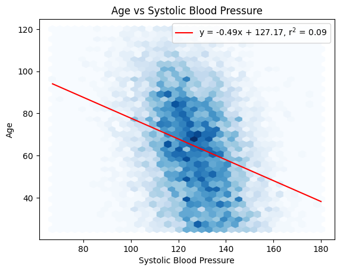

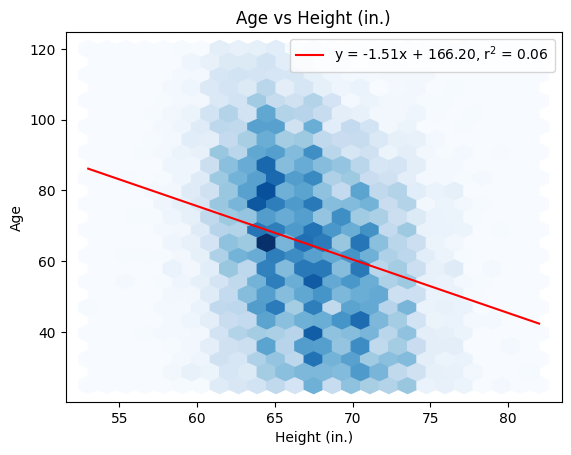

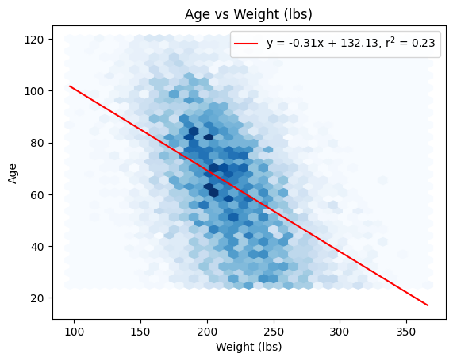

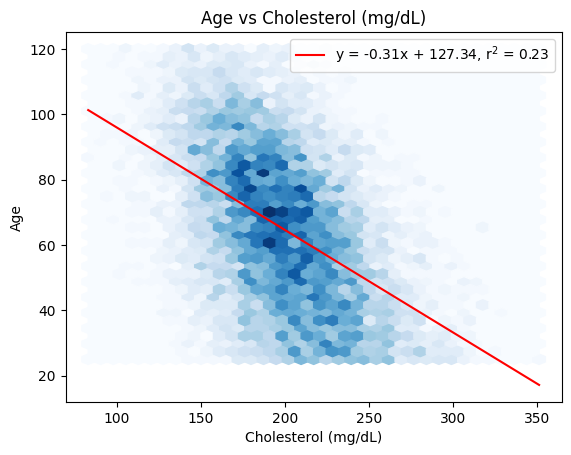

```python
plot_age_with_variable('sys_bp', 'Systolic Blood Pressure')
plot_age_with_variable('height', 'Height (in.)', 24)
plot_age_with_variable('weight', 'Weight (lbs)')
plot_age_with_variable('cholesterol', 'Cholesterol (mg/dL)')
```

### 3.1. Conclusion

Due to our low $r^2$ values, which tell us how much of the variation in our Y values, the age of death, from our line-of-best-fit to the actual data can be explained by our X values, our variable trait, we can see none of these factors correlate strongly with age of death, with our highest $r^2$ value being only 0.23.

However, we can see that all of the factors, especially for weight and cholesterol levels: if these factors increase, the age of death tends to decrease. Therefore, our initial exploration shows that higher weight and cholesterol levels has a tendency to correlate with earlier deaths.

#### Why does this matter?

Having an idea on how our dependent variable that we are investigating, the age of death, will be affected another variable can help us understand why we might get certain results in our analysis down the line.

### 3.2. Question: Do males and females have significantly different average ages at death?

Because our data contains not only numerical-based traits, but also text-based values to represent some of the characteristics of the people, we can do some comparisons between these characteristics based on trends we find in our numerical values. One thing we wanted to see is if the age of death might differ between men and women; maybe there is a factor in the longevity of humans that is dependent on biological gender.

In order to find this out, we are going to need to do some hypothesis testing.

**Hypothesis Testing** - a statistical method used to make informed decisions or draw conclusions about a population based on a sample of data.

8. Create our null and alternative hypotheses:

$\text{H}_{o}$ - There is no difference in the average age of death between males and females.

$\text{H}_{a}$ - There is a difference in the average age of death between males and females.

9. Prepare the data for analysis

```python
# Split by sex
male_ages = df[df['sex'] == 'm']['age']
female_ages = df[df['sex'] == 'f']['age']
```

```
T-statistic: -29.80
P-value: 0.0000
```

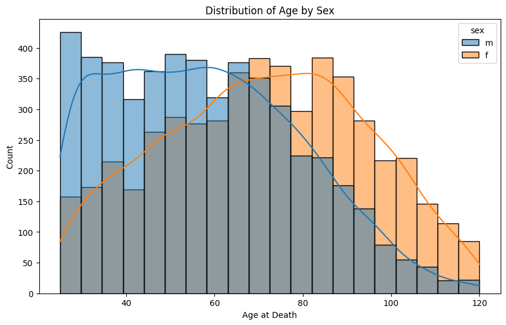

```python
### Performing the analysis ###
# T-Test
t_stat, p_value = stats.ttest_ind(male_ages, female_ages)

print(f"T-statistic: {t_stat:.2f}")
print(f"P-value: {p_value:.4f}")


### Visualizing the data ###
plt.figure(figsize=(10,6))
sns.histplot(data=df, x='age', hue='sex', bins=20, kde=True)
plt.title('Distribution of Age by Sex')
plt.xlabel('Age at Death')
plt.ylabel('Count')
plt.show()
```

### 3.2. Conclusion

Since the p-value is 0.0000 which is less than 0.05 we reject the null hypothesis which is that there is no difference in average age between males and females. From our plot we can see that females tend to die at older ages than males. We also have a T-statistic of -29.80 which is very large in magnitude and negative, which means that the mean age for males is significantly lower than the mean age for females.

### What does this mean?

There is statistical evidence that biological females will live longer than biological males! This can have a huge impact on predicting the age of death as such a factor like sex can either decrease or increase the age we find from a machine learning model.

### 3.3 Question: Does a history of Heart Disease/Stroke affect the Age of Death

Let's look into something more serious for this analysis. Given that HD/S are life-altering events in people's lives, we want to see how much of a difference they make in affecting the age at which a person dies. In order to do that, we must once again employ the T-Test

11. Create our null and alternative hypotheses

$\text{H}_{o}$ - There is no difference in the average age of death those who have suffered from Heart Disease/Stroke

$\text{H}_{a}$ - There is a difference in the average age of death those who have suffered from Heart Disease/Stroke

12. Prepare the data for analysis

```python
# Split by hds boolean values 'y'/'n'
hds_ages = df[df['hds'] == 'y']['age']
non_hds_ages = df[df['hds'] == 'n']['age']
```

```
HD/S Mean: 53.91
Non-HD/S Mean: 73.97
T-statistic: -47.83
P-value: 0.0000
```

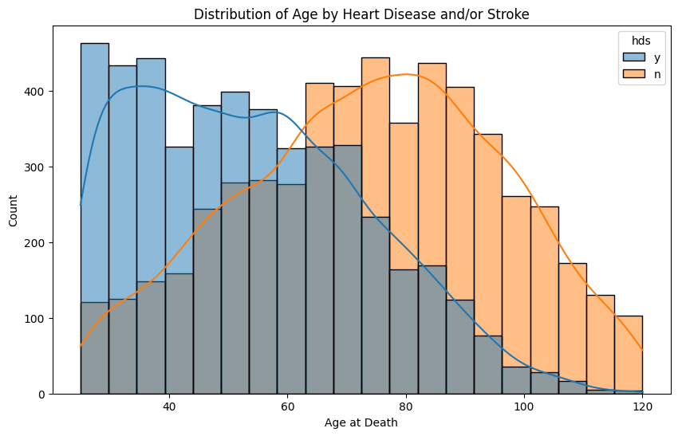

```python
### Performing the analysis ###
#Find the means
print(f"HD/S Mean: {hds_ages.mean():.2f}")
print(f"Non-HD/S Mean: {non_hds_ages.mean():.2f}")
# T-Test
t_stat, p_value = stats.ttest_ind(hds_ages, non_hds_ages)

print(f"T-statistic: {t_stat:.2f}")
print(f"P-value: {p_value:.4f}")


### Visualizing the data ###
plt.figure(figsize=(10,6))
sns.histplot(data=df, x='age', hue='hds', bins=20, kde=True)
plt.title('Distribution of Age by Heart Disease and/or Stroke')
plt.xlabel('Age at Death')
plt.ylabel('Count')
plt.show()
```

### 3.3. Conclusion

We can see with both the actual mean values and our p-value, which is equal to 0.000, that the means are significantly different from each other and that heart disease and/or stroke plays a major role in a person's longevity.

A few things that we can see from our answers and visualization:

- There is a 20 year difference between the means, meaning that a heart disease or a stroke could (with obvious variance) take away almost 20 years from a person's life
- It is easily visible that while the non-HD/S (heart disease or stroke) entries are normally distributed, the HD/S entries are [skewed](https://www.scribbr.com/statistics/skewness/) to the right, meaning having the HD/S trait tends to shorter lifespans than the average.

#### What does this mean?

When we do further analysis using multiple features, we will most likely see HD/S playing a major role in determining the age of death for any given set of independent variables, which will be the trait data we use.

### 3.4. Question: Drinks per Week vs. Age of Death

Our last hypothesis testing is going to be between the number of drinks a person consumes per week to their age of death. We think this is an important test to run as drinking doesn't necessarily show immediate affects to the degredation of longevity. However, using statistical analysis can help potentially paint a different, more realistic picture for those who don't believe that drinking can affect their health.

14. Create our null and alternative hypotheses

$\text{H}_{o}$ - The amount of weekly drinking does not have an affect on average death age.

$\text{H}_{a}$ - The amount of weekly drinking does have an affect on average death age.

15. Prepare the data

```python
### Preparing the data ###
# Defining boundaries to split the group
cut_boundaries = [0, 1, 10, 100] # Max number of drinks was 37, so this splits the df into groups of 0, 1-10, and 11+
cut_labels = ["0 drinks", "1-10 drinks", "11+ drinks"]

# Create a new column for group labels
df["Drinks Group"] = pd.cut(df["drinks_aweek"], bins=cut_boundaries, labels=cut_labels, include_lowest=True)

# Extracting groups
group_0 = df[df["Drinks Group"] == "0 drinks"]
group_1_10 = df[df["Drinks Group"] == "1-10 drinks"]
group_11_plus = df[df["Drinks Group"] == "11+ drinks"]
```

16. Perform [ANOVA](https://www.datacamp.com/tutorial/anova-test) testing on our 3 groups (Note: The reason we use ANOVA is to tell us if there significant differences between more than 2 groups.)

```python
### Performing the analysis ###
# ANOVA Test
f, p = stats.f_oneway(group_0["age"], group_1_10["age"], group_11_plus["age"])
print("ANOVA P-value: " + str(p))
```

```
ANOVA P-value: 0.0
```

```python
### Performing the post-analysis ###
# Create a list to loop through
combinations = [('0 drinks', '1-10 drinks'), ('0 drinks', '11+ drinks'), ('1-10 drinks', '11+ drinks')]

# Create a single group for easy looping
age_groups = df.groupby('Drinks Group', observed = False)['age']

print("\nTukey HSD Results: ")
# Doing Tukey's HSD as a Post-Hoc test for ANOVA
for group1, group2 in combinations:
    df1 = age_groups.get_group(group1)
    df2 = age_groups.get_group(group2)

    t, p = stats.ttest_ind(df1, df2)

    print(group1 + " vs. " + group2)
    print("T-val: " + str(t))
    print("P-val: " + str(p) + "\n")
```

```
Tukey HSD Results:
0 drinks vs. 1-10 drinks
T-val: 12.5505453870933
P-val: 1.1543045789054113e-35

0 drinks vs. 11+ drinks
T-val: 29.170447671492294
P-val: 3.1745837050131766e-172

1-10 drinks vs. 11+ drinks
T-val: 35.311579189385775
P-val: 9.593852461545505e-257
```

18. Visualize our results.

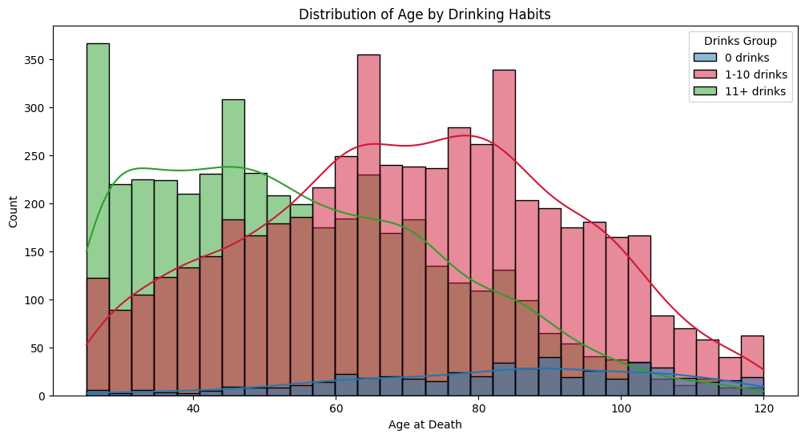

```python
### Visualizing the data ###
# Defining colors for plot
custom_palette = {
    "0 drinks": "#1f77b4",       # Blue
    "1-10 drinks": "#d11736",    # Red
    "11+ drinks": "#2ca02c"      # Green
}

# Plotting
plt.figure(figsize=(12,6))
sns.histplot(data=df, x='age', hue='Drinks Group', bins=30, kde=True, palette=custom_palette)
plt.title('Distribution of Age by Drinking Habits')
plt.xlabel('Age at Death')
plt.ylabel('Count')
plt.show()
```

### 3.4. Conclusion

Based on the p-value, we reject the null hypothesis. The p value was extremely small (p $\approx$ 0.00), meaning that the probability we would observe the current data if the null hypothesis was true is essentially zero.

Looking at the plot, we can clearly see that the mean age of death is inversely proportional to the frequency of drinking, meaning that the average age of death increases as the weekly average of drinks decreases.

One caveat to this conclusion is that the sample size for the group with zero drinking is smaller (~500) when compared to the other two groups (roughly 5200 and 4200 for 1-10 drinks and 11+ drinks respectively). However, 500 is still a large sample size and the trend is very clear, so the results are still reliable.

## 4. Primary Analysis

Now onto the meat of our report tutorial:

### What Characteristics and Lifestyle Choices Predict Longer Lifespans?

### 4.1. Linear Regression

In this section, we trained a [**linear regression model**](https://scikit-learn.org/stable/modules/generated/sklearn.linear_model.LinearRegression.html) to explore how different physical and lifestyle features relate to **age at death**. The goal was to uncover which factors—like blood pressure, substance use, or medical history—might be associated with living longer.

Using the cleaned dataset, we selected a mix of numerical and binary features related to health and behavior. we split the data into training and testing sets, trained a regression model using scikit-learn, and evaluated how well the model predicted lifespan.

This analysis allows us to predict lifespan based on measurable inputs and also gives us **interpretable coefficients** that help identify which traits have a strong positive or negative impact on longevity.

19. Organize and Format our data to be better suited for linear regression

```python
### Organizing and format the data ###
# Convert 'y'/'n' to 1/0 for columns with binary responses
# *Note* This is a form of One Hot encoding which you can learn more about here:
# https://www.geeksforgeeks.org/ml-one-hot-encoding/
binary_columns = [
    'smoker', 'nic_other', 'cannabis', 'opioids', 'other_drugs', 'addiction',
    'diabetes', 'hds', 'asthma', 'immune_defic',
    'family_cancer', 'family_heart_disease', 'family_cholesterol',
    'occup_danger', 'ls_danger'
]
df[binary_columns] = df[binary_columns].replace({'y': 1, 'n': 0}).infer_objects(copy=False)

# Select features and target
features = [
    'height', 'weight', 'sys_bp', 'cholesterol',
    'smoker', 'nic_other', 'drinks_aweek', 'cannabis', 'opioids', 'other_drugs', 'addiction',
    'diabetes', 'hds', 'asthma', 'immune_defic', 'num_meds', 'major_surgery_num',
    'family_cancer', 'family_heart_disease', 'family_cholesterol',
    'occup_danger', 'ls_danger'
]

# Select which columns are going to be our Independent Variables (X)
# and which column will be our Dependent Variable (Y)
X = df[features]
y = df['age']
```

19. Train and Evaluate our Linear Regression Model

```python
### Perform Training, Testing, and Evaluation ###
# Split data
X_train, X_test, y_train, y_test = train_test_split(X, y, test_size=0.2, random_state=42)

# Train linear regression model
model = LinearRegression()
model.fit(X_train, y_train)

# Make predictions
y_pred = model.predict(X_test)

# Evaluate model
mae = mean_absolute_error(y_test, y_pred)
r2 = r2_score(y_test, y_pred)

print(f"Mean Absolute Error: {mae:.4f}")
print(f"R-squared: {r2:.4f}")
```

```
Mean Absolute Error: 11.2396
R-squared: 0.6465
```

### 4.1. Conlusion

Our final **R^2** value was **0.6465**, which shows our linear regression model was somewhat able to find a relationship between our features and age of death. The fact that it is not closer to 1.0 could be because there are other factors not considered in the dataset that contribute significantly to age of death. For example, socioeconomic status could be a highly important factor.

Note: We did not include gender in our Regression Model. We wanted to see how conditions and traits related to lifestyle choices affected lifespan, and gender did not fit within those parameters.

### 4.2. Testing other Regression Models

Additionally, we decided to try out higher order polynomial regression and ridge/lasso regression, to see if these methods could better capture the relationship between the data, which would be shown by improving our model's R-squared and reducing error.

#### Polynomial Regression

20. Train and Evaluate [Polynomial Regression Model](http://scikit-learn.org/stable/modules/generated/sklearn.preprocessing.PolynomialFeatures.html)

```python
# Create 2nd order regression
poly_model = make_pipeline(PolynomialFeatures(degree=2), LinearRegression())

# Train model
poly_model.fit(X_train, y_train)

# Making predictions
y_poly_pred = poly_model.predict(X_test)

# Evaluating
poly_mae = mean_absolute_error(y_test, y_poly_pred)
poly_r2 = r2_score(y_test, y_poly_pred)

print(f"[Polynomial Regression]")
print(f"Mean Absolute Error: {poly_mae:.4f}")
print(f"R-squared: {poly_r2:.4f}")
```

```
[Polynomial Regression]
Mean Absolute Error: 11.0592
R-squared: 0.6510
```

We also tried polynomial models with a higher order (3+). When the model was of degree 3, the resulting MAE was 15.35 and the R-squared was -1.20. Additionally, the model took approximately 7x longer to converge. Higher order models (4+) did not converge within the computational limits that are present (Colab ran out of RAM)

#### Ridge (and Lasso) Regression

21. Train and Evaluate our [Ridge Regression Model](https://scikit-learn.org/stable/modules/generated/sklearn.linear_model.Ridge.html)

```python
# Trying different alpha values to check impact
alphas = [0.001, 0.01, 0.1, 1, 10, 100]
print(f"[Ridge Regression]")

for a in alphas:
    # Creating and training the model
    ridge_model = make_pipeline(PolynomialFeatures(degree=2, include_bias=False), Ridge(alpha=a))
    ridge_model.fit(X_train, y_train)

    # Making predictions
    ridge_y_pred = ridge_model.predict(X_test)

    # Evaluating
    ridge_mae = mean_absolute_error(y_test, ridge_y_pred)
    ridge_r2 = r2_score(y_test, ridge_y_pred)
    print(f"Alpha: {a}, Mean Absolute Error: {ridge_mae:.4f}, R²: {ridge_r2:.4f}")
```

```
[Ridge Regression]
Alpha: 0.001, Mean Absolute Error: 11.0592, R²: 0.6510
Alpha: 0.01, Mean Absolute Error: 11.0591, R²: 0.6510
Alpha: 0.1, Mean Absolute Error: 11.0587, R²: 0.6510
Alpha: 1, Mean Absolute Error: 11.0566, R²: 0.6512
Alpha: 10, Mean Absolute Error: 11.0592, R²: 0.6510
Alpha: 100, Mean Absolute Error: 11.0550, R²: 0.6516
```

We did also try Lasso Regression, but ultimately did not continue with this methodology - The model was not converging within a number of iterations that were computationally available to us. This could be due to the difference between features like height, as well as binary features like smoking/no-smoking. These variables are on very different scales, which can cause issues with Lasso Regression.

## 4. Conclusion

We chose a **linear regression model** because we’re trying to predict age at death, which is a continuous number—not a category—so regression makes the most sense. Our data includes a mix of yes/no lifestyle choices (e.g., whether someone smokes) and numerical health stats (like blood pressure or cholesterol), which work really well with this kind of model.

One of the reasons we liked linear regression is that it doesn’t just make predictions—it also shows us how each factor affects lifespan. The model gives us coefficients that tell us whether a particular habit or condition is linked to living longer or shorter and by how much. That kind of insight is exactly what we were looking for.

Because our dataset isn’t huge, we also considered using Ridge or Lasso regression. These slightly more advanced versions help avoid overfitting and make the results more reliable. They’re especially useful when some features are closely related or redundant.

## 5. Visualization

### 5.1. Visualizing Model Response

Now that we have picked our model for predicting the age of death given our features, lets visualize it! Let's see how our model's predictions visually compare to the actual data.

22. Visualize our Linear Regression Model

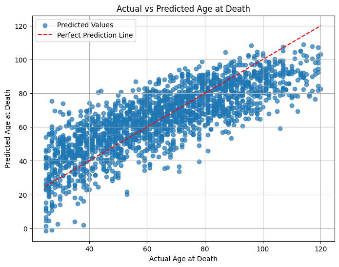

```python
# Plot true vs predicted values
plt.figure(figsize=(8,6))
plt.scatter(y_test, y_pred, alpha=0.7, label="Predicted Values")
plt.plot([y.min(), y.max()], [y.min(), y.max()], color='red', linestyle='--', label="Perfect Prediction Line")
plt.xlabel("Actual Age at Death")
plt.ylabel("Predicted Age at Death")
plt.title("Actual vs Predicted Age at Death")
plt.legend()
plt.grid(True)
plt.show()
```

We create a scatter plot of actual vs. predicted age at death, with each dot representing a person. The red dashed line shows perfect predictions. Points above the red line represent our model predicting a longer lifespan than reality, and points below the line represent the model predicting a shorter lifespan than reality. Most points follow a clear upward trend, suggesting acceptable model performance. The Mean Absolute Error was 11.24, meaning predictions were off by about 11 years on average. The R-squared score was 0.65, indicating that our model explains 65% of the variation in age at death.

### 5.2. Visualizing Importance of Traits

When you train a model, what you are essentially doing is adjusting a set of coefficients, also known as "weights", that control the end behavior of our machine learning model. Because the data we use changes the weights behaviour, we can use these weights to then analyze which features actually made the most difference in our model. Here, we visualize those differences in the form of feature importances.

23. Find the feature importances of our data and create a bar chart to visualize their importance

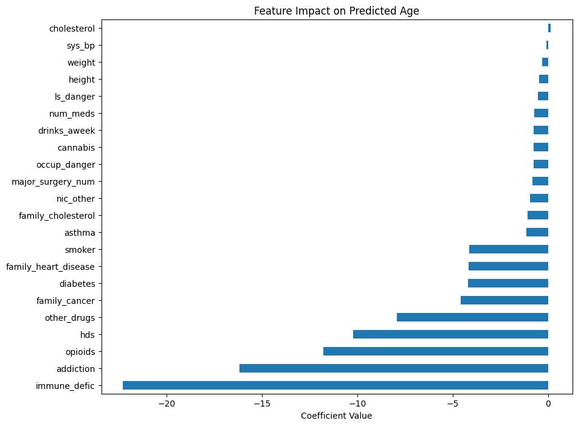

```python
# Showing feature importances (coefficients)
coeffs = pd.Series(model.coef_, index=features)
coeffs.sort_values().plot(kind='barh', figsize=(10,8), title="Feature Impact on Predicted Age")
plt.xlabel("Coefficient Value")
plt.show()
```

This bar chart of feature importance shows how each trait affects predicted age. Features like immune deficiency, addiction, and opioid use were linked to significantly lower predicted lifespan, while others like cholesterol and blood pressure had minimal effects. These visualizations highlight which factors most strongly relate to lifespan in our dataset.

After creating the plot, we noticed is that although a given feature may have a strong relationship with age of death, that does not directly translate to having a high importance in the regression. For example, during our exploratory data analysis, we found that there is a significant difference in age of death for HD/S vs. Non-HD/s, and also as the number of drinks per week varies. However, while having HD/S versus not was an important feature to the model, the number of drinks was not.

### 5.3. Post-Visualization Analysis

Similarly, we noticed how certain features that would intuitively be correlated do not all share the same feature importance. For example, one would intuitively think that weight and diabetes would be very strongly related. However, diabetes has a high importance to the model, while weight has a comparatively much lower importance. This likely means that when presented with multiple features that encode very similar information, our model is likely choosing only one or a few of these features to have a high impact, while downweighting the others. After noticing this, we decided to create a heatmap of our feature correlations, in order to confirm or deny this suspicion.

24. Create a [heatmap](https://seaborn.pydata.org/generated/seaborn.heatmap.html)

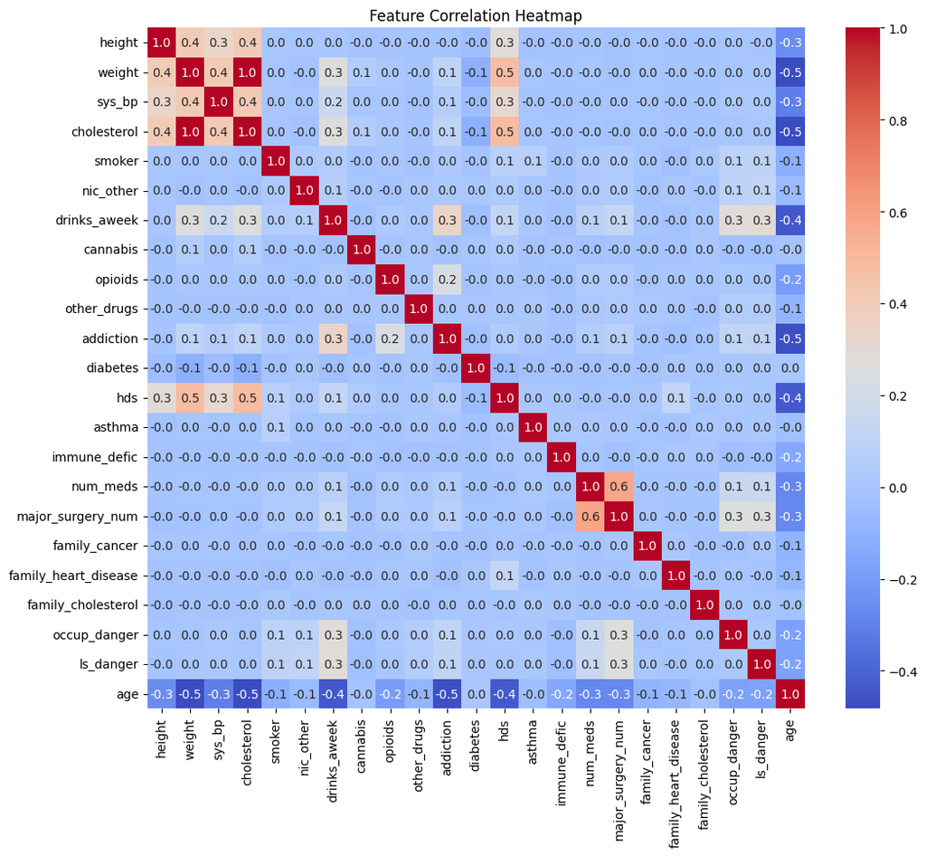

```python
# Create a heatmap showcasing the correlations between features
plt.figure(figsize=(12, 10))
sns.heatmap(df[features + ['age']].corr(), annot=True, fmt=".1f", cmap="coolwarm")
plt.title("Feature Correlation Heatmap")
plt.show()
```

After viewing the heatmap, it became clear that outside of a few notable exceptions, the various features are generally not correlated with each other. In fact, weight and diabetes were not correlated, as previous postulated. However, weight and cholesterol had a correlation of 1, meaning both features contain the same exact data.

## 6. Insights and Conclusions

Ultimately, we have found that there are many factors that contribute significantly to age of death. Our linear regression model was able to give acceptable predictions on age of death, showing that the features we considered do indeed correlate with lifespan.

It can be seen from our feature impact ranking that there are many things that a person can do, which correlate to living longer. For example, smoking or other drug use can lead to significantly short lifespan. However, it is also clear that many factors are not directly controllable by the individual. For example, family history of cancer or immune deficiencies have heavy negative correlations with lifespan. More complicated factors like addiction (which is affected by many things: genetics, family history, socioeconomic status, etc…), also can heavily reduce lifespan. These non-controllable or complicated factors tend to have the highest impact on mortality.

Medical professionals may be able to use these findings to determine which risk factors of a patient to pay the most attention to. Addictions, family history of disease, and drug use are factors that any medical professional should consider strongly when deciding on the need for treatment.